# L02 统计学导论B-实验课02

郑盼盼

2024-09-18

## 2.0 变量赋值

- **变量名**：变量名仅包含任何大小写字母,数字 以及下划线`_`（但数字和下划线不能用于变量名开头）；且要注意区分大小写 $\mathrm{a\neq A}$，比如，如下的语句就会报错

  ```r
  a <- 1
  A
  ```

- 三个赋值符号：
  1. `<-` (在RStudio中可以使用快捷键 `alt/option + -` 快速插入)
  2. `=`
  3. `->`
- 以将变量 `a` 赋值为 `1` 为例，以下三种赋值方式等价

  ```r
  a <- 1
  a = 1   # 注意：变量名必须在等号的左侧，而值在等号的右侧
  1 -> a
  ```

## 2.1 变量类型

> R语言中变量类型主要包括逻辑型，数值型和字符型三类

> 可以使用 `class(变量名)` 的方式查看变量的类型

### 2.1.1 逻辑型 (logical)

- 逻辑型 (logical)：即对于“对(True)”或“错(False)”的表述。仅有 `TRUE` （可简写为 `T`） 和 `FALSE` （可简写为 `F`）两类。

  ```r
  # l1,l2,l3, l4 均为逻辑型变量
  l1 <- TRUE
  l2 <- FALSE
  l3 <- T  # 等价于l1
  l4 <- F  # 等价于l2

  paste("l1 = ", l1, ", l1 is ", class(l1))
  ```

  ```
  ## [1] "l1 =  TRUE , l1 is  logical"
  ```

  ```r
  paste("l2 = ", l2, ", l2 is ", class(l2))
  ```

  ```
  ## [1] "l2 =  FALSE , l2 is  logical"
  ```

  ```r
  paste("l3 = ", l3, ", l3 is ", class(l3))
  ```

  ```
  ## [1] "l3 =  TRUE , l3 is  logical"
  ```

  ```r
  paste("l4 = ", l4, ", l4 is ", class(l4))
  ```

  ```
  ## [1] "l4 =  FALSE , l4 is  logical"
  ```

- 试试看下面三个语句的结果，并判断结果是什么类型的变量
  1. `1 > 2`
  2. `1 == 0`
  3. `1 != 0`
- 我们可以使用 `is.logical(变量)` 的方式判断一个变量是否为逻辑型

  ```r
  x <- 1 > 2
  is.logical(x)
  ```

  ```
  ## [1] TRUE
  ```

  ```r
  is.logical(1 > 2)
  ```

  ```
  ## [1] TRUE
  ```

### 2.1.2 数值型 (numeric)

- 数值型 (numeric)：例如人的身高，体重，学生的成绩。我们可以用一个数值来表述这些性质。

  ```r
  # n1, n2, n3, n4 均为数值型变量。R语言默认存储为浮点型
  n1 <- 3
  n2 <- 1/3
  n3 <- 0.33333
  n4 <- 3.3333e-1   # 科学计数法：3.3333e-1 等同于 3.3333 * (10^-1)

  paste("n1 = ", n1,", n1 is the ", class(n1))
  ```

  ```
  ## [1] "n1 =  3 , n1 is the  numeric"
  ```

  ```r
  paste("n2 = ", n2,", n2 is the ", class(n2))
  ```

  ```
  ## [1] "n2 =  0.333333333333333 , n2 is the  numeric"
  ```

  ```r
  paste("n3 = ", n3,", n3 is the ", class(n3))
  ```

  ```
  ## [1] "n3 =  0.33333 , n3 is the  numeric"
  ```

  ```r
  paste("n4 = ", n4,", n4 is the ", class(n4))
  ```

  ```
  ## [1] "n4 =  0.33333 , n4 is the  numeric"
  ```

- 试试看：
  1. `TRUE + TRUE`
  2. `TRUE - FALSE`
  3. `3 + FALSE`

### 2.1.3 字符型 (character)

- 字符型 (character)：例如人的性别 (gender)，姓名。一般我们使用一串字符来表示这些性质，字符型变量两边由 `"` 或 `'` 包裹。

  ```r
  c1 = "TRUE"
  c2 = "FALSE"
  c3 = "this is 'test'"    # 若希望在字符串中加'可以在外侧用"
  c4 = 'this is \'test\''  # 也可以在'前加\实现字符的转意
  print(c1)
  ```

  ```
  ## [1] "TRUE"
  ```

  ```r
  print(c2)
  ```

  ```
  ## [1] "FALSE"
  ```

  ```r
  print(c3)
  ```

  ```
  ## [1] "this is 'test'"
  ```

  ```r
  print(c4)
  ```

  ```
  ## [1] "this is 'test'"
  ```

- 试试看
  1. `'this is "test"'`
  2. `"this is \"test\"`

### 2.1.4 不同类型之间的相互转换

- 转化为数值型 `as.numeric()`

  ```r
  a <- "123"
  as.numeric(a)
  ```

  ```
  ## [1] 123
  ```

  ```r
  b <- T
  as.numeric(b)
  ```

  ```
  ## [1] 1
  ```

- 转化为字符型 `as.character()`

  ```r
  a <- T
  as.character(a)
  ```

  ```
  ## [1] "TRUE"
  ```

  ```r
  b <- 1e-3
  as.character(b)
  ```

  ```
  ## [1] "0.001"
  ```

- 转化为逻辑型 `as.logical()` 一切非零的数值都会被转化为 `TRUE`，而零会被转化为 `FALSE`

  ```r
  a <- 1
  as.logical(a)
  ```

  ```
  ## [1] TRUE
  ```

  ```r
  b <- -1
  as.logical(b)
  ```

  ```
  ## [1] TRUE
  ```

  ```r
  c <- 0
  as.logical(c)
  ```

  ```
  ## [1] FALSE
  ```

- 对于无法转换的类型，R会自动转化为 `NA` 即缺失值

  ```r
  a <- "0"
  as.logical(a)
  ```

  ```
  ## [1] NA
  ```

  ```r
  b <- "1this is characters"
  as.numeric(b)
  ```

  ```
  ## [1] NA
  ```

### 2.1.5 特殊常量

| 变量名 | 含义 |
| --- | --- |
| `pi` | 圆周率，3.1415… |
| `Inf` | 无穷大 `1/0` |
| `NaN` | 不定量，`0/0` |
| `NA` | 缺失值 |

```r
pi
```

```
## [1] 3.141593
```

```r
1/0
```

```
## [1] Inf
```

```r
0/0
```

```
## [1] NaN
```

```r
NA
```

```
## [1] NA
```

## 2.2 常用数据结构

[figure not shown]

### 2.2.1 向量 (vector)

$$\begin{bmatrix}
1 & 2 & 3 & 4
\end{bmatrix}$$

#### 生成向量

- 通过 `c()` 来生成向量，只用按顺序输入向量的各个分量即可

  ```r
  v1 <- c(1,2,3,4)
  v1
  ```

  ```
  ## [1] 1 2 3 4
  ```

- 对于 $[1,2,3,4,5,...,n]$ 这样的等差数列，可以使用 `1:n` 来直接生成

  ```r
  v2 <- 1:4
  v2
  ```

  ```
  ## [1] 1 2 3 4
  ```

- 对于有规则的等差数列，可以使用 `seq()` 来生成

  ```r
  seq(-2, 3, by=0.5) # 公差为 0.5，首项为-2，尾项最接近3的等差数列
  ```

  ```
  ##  [1] -2.0 -1.5 -1.0 -0.5  0.0  0.5  1.0  1.5  2.0  2.5  3.0
  ```

  ```r
  seq(2, 4, length.out=4) # 生成首项和尾项分别为2和4的4维向量
  ```

  ```
  ## [1] 2.000000 2.666667 3.333333 4.000000
  ```

  ```r
  seq(2, by=0.5, length=4)  # 生成首项为2，公差为0.5，长度为4的向量
  ```

  ```
  ## [1] 2.0 2.5 3.0 3.5
  ```

- **注意**：向量中的数据类型需要保持一致，否则会出现强制转换!优先级为 `字符型 > 数值型 > 逻辑型` （优先级低的类型会被强制转换为优先级高的类型）

  ```r
  c(1,2,"3")    # 字符型最优先
  ```

  ```
  ## [1] "1" "2" "3"
  ```

  ```r
  c(1,2,TRUE)   # 其次是数值型
  ```

  ```
  ## [1] 1 2 1
  ```

#### 元素的索引和修改

- 使用 `a[i]` 来索引向量 `a` 中第 `i` 个元素

  ```r
  a <- c(1,2,3)
  a[2]
  ```

  ```
  ## [1] 2
  ```

- `a[i]` 中的 `[i]` 也可以是个列表

  ```r
  b <- c(2,2,2,1,3)
  a[b]
  ```

  ```
  ## [1] 2 2 2 1 3
  ```

  ```r
  c <- a >= 2    # 返回一个由逻辑值组成的向量
  a[c]
  ```

  ```
  ## [1] 2 3
  ```

- 通过对第 `i` 个元素进行赋值，来修改向量中第 `i` 个元素的值

  ```r
  a <- c(1,2,3)
  a[1] <- 100
  a
  ```

  ```
  ## [1] 100   2   3
  ```

  ```r
  a[2] = 300
  a
  ```

  ```
  ## [1] 100 300   3
  ```

### 2.2.2 矩阵 (matrix)

- 为向量的推广，其元素具有**相同的数据类型**

#### 矩阵的创建

- 通过函数 `matrix(x,m,n)` 的形式来生成矩阵（将向量 `x` 转换为 `m` 行 `n` 列的矩阵）
  - **列优先**

    ```r
    a <- 1:6
    m1 <- matrix(a, 3, 2)
    m1
    ```

    ```
    ##      [,1] [,2]
    ## [1,]    1    4
    ## [2,]    2    5
    ## [3,]    3    6
    ```

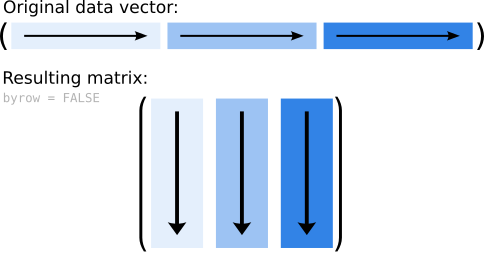

    默认为列优先

  - **行优先**

    ```r
    a <- 1:6
    m2 <- matrix(a, 3, 2, byrow=T)
    m2
    ```

    ```
    ##      [,1] [,2]
    ## [1,]    1    2
    ## [2,]    3    4
    ## [3,]    5    6
    ```

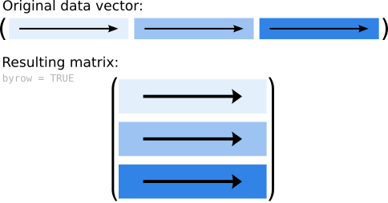

    通过`byrow=T`改为行优先

- **注意** 和向量一样，当矩阵中元素的类型不同时，也会强制转换元素类型：优先级也是 `字符型 > 数值型 > 逻辑型` （优先级低的类型会被强制转换为优先级高的类型）
  - 尝试如下代码:

    ```r
    a1 <- c(1,2,3,4,"5",6)
    m3 <- matrix(a1, 3,2)
    m3


    a2 <- c(T,2,3,4,5,6)
    m4 <- matrix(a2, 3,2)
    m4
    ```

#### 矩阵的索引和元素的修改

- 和向量类似我们用 `a[i,j]` 的形式索引矩阵第 `i` 行 (row)，第 `j` 列 (column) 的元素;

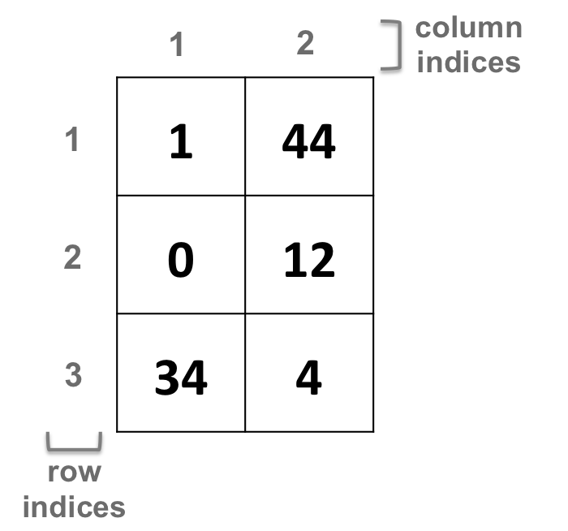

  ```r
  x <- 1:9
  m <- matrix(x, 3, 3)
  m
  ```

  ```
  ##      [,1] [,2] [,3]
  ## [1,]    1    4    7
  ## [2,]    2    5    8
  ## [3,]    3    6    9
  ```

  ```r
  m[3,2] # 矩阵m第3行第2列的元素
  ```

  ```
  ## [1] 6
  ```

- 和向量类似，我们也可以用一组向量来索引矩阵

  ```r
  i <- c(1,3)
  j <- c(1,2)
  m[i,j] # 挑选出第1行和第1,2列，第3行和第1,2列相交的元素组成新的矩阵
  ```

  ```
  ##      [,1] [,2]
  ## [1,]    1    4
  ## [2,]    3    6
  ```

- 索引某一列或某一行 `a[,n]` `a[m,]`

  ```r
  m[3,] # 索引第3行
  ```

  ```
  ## [1] 3 6 9
  ```

  ```r
  m[,2] # 索引第2列
  ```

  ```
  ## [1] 4 5 6
  ```

- 我们同样可以用赋值的方式来修改矩阵中元素的值

  ```r
  x <- 1:9
  m <- matrix(x, 3, 3)
  m
  ```

  ```
  ##      [,1] [,2] [,3]
  ## [1,]    1    4    7
  ## [2,]    2    5    8
  ## [3,]    3    6    9
  ```

  ```r
  i <- c(1,3)
  j <- c(1,2)
  m[i,j] <- 1:4  # 挑选出第1行和第1,2列，第3行和第1,2列相交的元素组成新的矩阵
  m
  ```

  ```
  ##      [,1] [,2] [,3]
  ## [1,]    1    3    7
  ## [2,]    2    5    8
  ## [3,]    2    4    9
  ```

### 2.2.3 数据框 (data frame)

- 属于矩阵的一种拓展形式，类似于我们常见的表格：每一行代表每一个 subject 的数据，每一列代表不同的数据（可能拥有不同的数据类型）

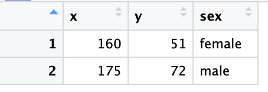

#### 数据框的创建

- `data.frame()`

  ```r
  x <- c(160, 175)
  y <- c(51, 72)
  sex <- c("female", "male")
  df <- data.frame(x,y,sex)                  # 使用列变量名 (x, y, sex)
  df2 <- data.frame(height=x, weight=y, sex) # 设置列变量名分别为(height, weight, sex)
  ```

#### 数据框的索引

- `names()` 用于显示数据框各列的名称

  ```r
  names(df)
  ```

  ```
  ## [1] "x"   "y"   "sex"
  ```

  ```r
  names(df2)
  ```

  ```
  ## [1] "height" "weight" "sex"
  ```

- **对列进行索引**：使用 `df$列变量` 对于数据框的列进行索引，也可使用 `df[j]` 直接检索第 `j` 列

  ```r
  df$sex
  ```

  ```
  ## [1] "female" "male"
  ```

  ```r
  df[3]
  ```

  | sex |
  | --- |
  | female |
  | male |

  ```r
  df2$height
  ```

  ```
  ## [1] 160 175
  ```

  ```r
  df2[2]
  ```

  | weight |
  | --- |
  | 51 |
  | 72 |

- **对行进行索引**：使用 `df[i,]` 索引第 `i` 行 (**注意 `i` 后面有个 `,`**)

  ```r
  df[1,]
  ```

  |  | x | y | sex |
  | --- | --- | --- | --- |
  | 1 | 160 | 51 | female |

  ```r
  df2[2,]
  ```

  |  | height | weight | sex |
  | --- | --- | --- | --- |
  | 2 | 175 | 72 | male |

- **对于元素进行索引**：使用 `df$x[i]` 索引第 `i` 个 subject 的 `x` 属性，类似于矩阵，我们也可以用行和列的方式进行索引 `df[i,j]` 索引第`i`行第 `j` 列的元素。

  ```r
  df$x[1]
  ```

  ```
  ## [1] 160
  ```

  ```r
  df[1,1]
  ```

  ```
  ## [1] 160
  ```

### 2.2.3 列表 (list)

- 列表可以视为向量在另一个方面的拓展，其内部可以存储不同类型的数据，且可根据键值 (key)进行索引

#### 列表的生成

- `list(key1=value1,key2=value2, ...)`

  ```r
  list1 <- list(1,"2",3)
  list1
  ```

  ```
  ## [[1]]
  ## [1] 1
  ##
  ## [[2]]
  ## [1] "2"
  ##
  ## [[3]]
  ## [1] 3
  ```

  ```r
  list2 <- list(x=1, y="2", z=3) # x,y,z 为我们索引使用的键值
  list2
  ```

  ```
  ## $x
  ## [1] 1
  ##
  ## $y
  ## [1] "2"
  ##
  ## $z
  ## [1] 3
  ```

#### 列表的索引

- 若我们像向量一样进行索引 `a[i]` 我们得到的还是一个列表而非列表内的值

  ```r
  class(list1[1]) # 运行后我们可以发现 list1[1] 返回的还是一个列表
  ```

  ```
  ## [1] "list"
  ```

- 我们需要使用 `a[[i]]` 才能得到具体的数值

  ```r
  class(list1[[1]]) # list[[1]] 返回的才是具体的元素值
  ```

  ```
  ## [1] "numeric"
  ```

- 类似于数据框，当我们定义键值后，可以使用 `list2$key` 来进行索引，这时可直接得到列表内元素的值

  ```r
  list2$y
  ```

  ```
  ## [1] "2"
  ```

  ```r
  class(list2$y) # $key 的方式可以直接返回列表的元素值
  ```

  ```
  ## [1] "character"
  ```

## 2.3 数值的基础运算和常用函数

- 基础运算：`+` `-` `*` `/` `^`

  ```r
  1 + 2 * 10    # 乘除以的优先级高于加减
  ```

  ```
  ## [1] 21
  ```

  ```r
  (1 + 2) * 10  # () 可以提高计算的优先级
  ```

  ```
  ## [1] 30
  ```

  ```r
  2 ^ 3     # 2的3次方
  ```

  ```
  ## [1] 8
  ```

  ```r
  2 ** 3    # 2的3次方, 同上
  ```

  ```
  ## [1] 8
  ```

- 常用函数
  1. **指数函数**：`exp(x)` $e^{x}$ ($e\approx 2.718281828459045$ 称为自然常数)

     ```r
     x <- seq(-5,2,by=0.001)
     y = exp(x)
     ```

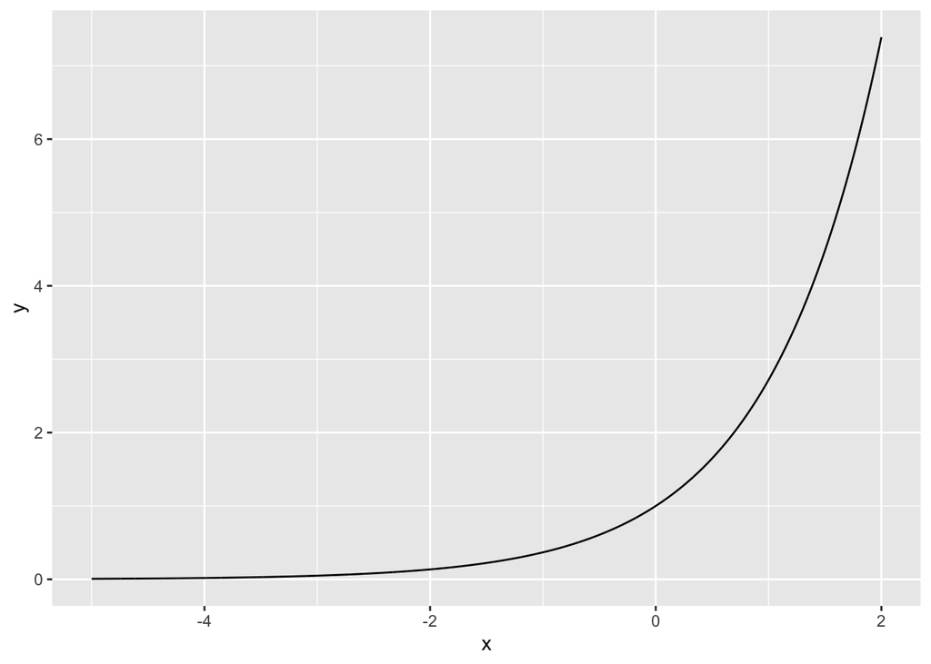

  2. **对数函数**：
     - `log(x)` $\ln(x)$
     - `log(x, base=n)` $\log_{n} x$

     ```r
     x <- seq(exp(-5),exp(2), by=0.001)
     y = log(x)
     ```

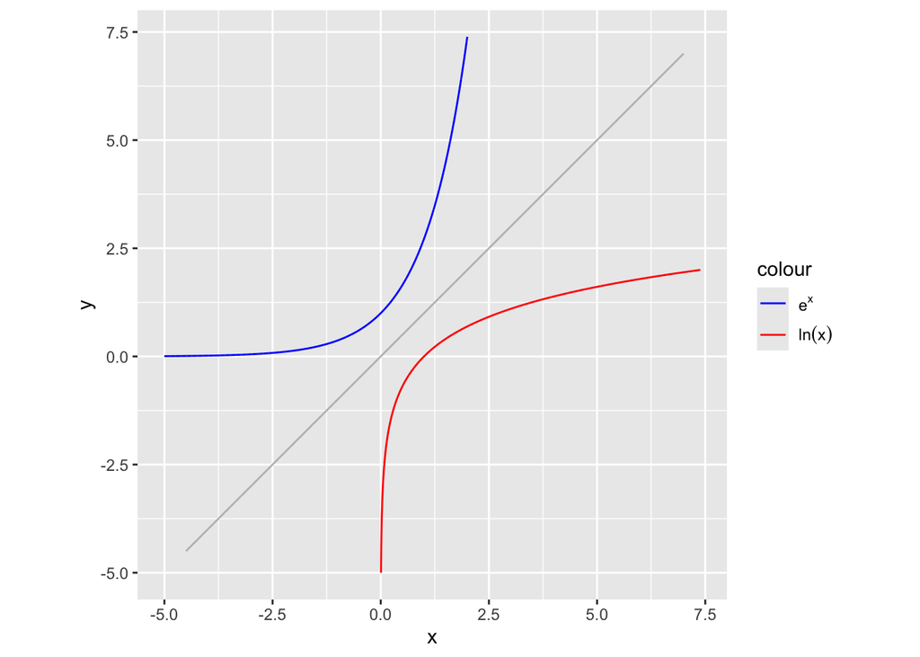

  3. **三角函数**：`sin(x)` `cos(x)` 其中`x` 采用弧度制

     ```r
     x <- seq(-3* pi,3*pi,by=1e-3)
     y_sin = sin(x)
     y_cos = cos(x)
     ```

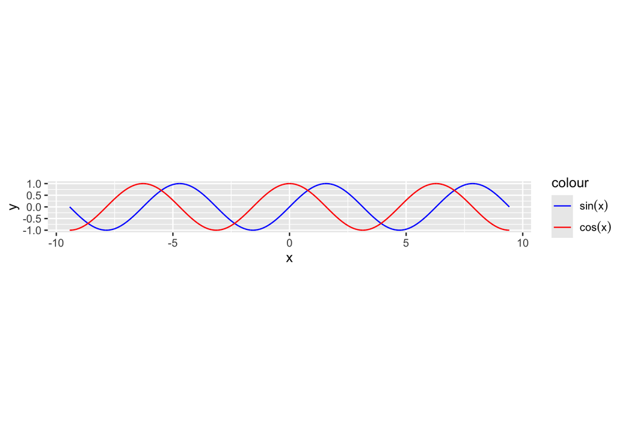

  4. `sum(x)` 求和函数：计算数值型向量 `x` 的所有元素的和；对于矩阵我们有 `colSums()` 对矩阵的列求和，`rowSums()` 对矩阵的行求和。

  ```r
  exp(1)
  ```

  ```
  ## [1] 2.718282
  ```

  ```r
  log(exp(1))
  ```

  ```
  ## [1] 1
  ```

  ```r
  log(2^3, base=2) # 以2为底，8的对数
  ```

  ```
  ## [1] 3
  ```

  ```r
  sin(pi/6)
  ```

  ```
  ## [1] 0.5
  ```

  ```r
  x <- 1:9
  sum(x)
  ```

  ```
  ## [1] 45
  ```

  ```r
  m <- matrix(x,3,3)
  colSums(m)
  ```

  ```
  ## [1]  6 15 24
  ```

  ```r
  rowSums(m)
  ```

  ```
  ## [1] 12 15 18
  ```

## Summary

1. 常见的变量类型：
2. **逻辑型**：逻辑型的定义；逻辑型和数值型之间的转换；
3. **数值型**：数值型的定义，科学计数法；
4. **字符型**：字符型的定义；如何在字符串中引入 `'` 或 `"`；